# analysis_uown

C. Coleman

10/27/2021

# UOWN Data Analysis for Determining Correlation Between Stream Health Indicators.

*The following markdown conducts the statistical analysis of how different indicators of stream health can potentially predict each other. In the previous processing script, the main take away was that there were very few significant relationships between different chemical, fecal/microbial and biological indicators. The only significant relationships found between Turbity and E. Coli CFU. However, It struck me as peculiar to see biological indicator score and conductivity to have only one significant relationship. After further review of the exploratory figures, I now want to assess the data and relationships explored thus far for impact of outliers, determine if it is appropriate to remove outlying values, and see if this helps find more significant relationships.* *The second part will include test/train splitting to predict stream health indicator values in the MIDO data set and assess the fit of linear models to the MIDO data. This is a more depth recreation of the linear model exploration. Obviously, we found that there weren’t any significant relationships in exploratory analysis. However, this gives us a chance to assess how good a fit the models are in order to see if its even worth looking at the relationships.*

*Therefore, the following constitutes the statistical analysis protocol that will be conducted in this markdown:*  
#### PART 1: Outliers in stream health indicator (Biological Score, E. Coli (cfu), Conductivity, NO3 (mg/L), and Turbidity) linear relationships. *1. Assess each linear relationship previously performed for outliers in the data;* *2. Determine if it is appropriate to remove outliers;* *3. Rerun linear regressions for the different stream health indicator relationships and assess if more significant relationships exist.*

#### PART 2: Linear Model Fit Analysis of MIDO Data

*1. Conduct test/train data splitting for MIDO Data.* *2. Conduct linear modeling for relationships between stream health indicator predictors (Biological Score, E. Coli (cfu), Conductivity, NO3 (mg/L), and Turbidity) in the form of a workflow for the Test and Train MIDO data.* *3. Predict values for Test and Train MIDO data.* *4. Assess how well the MIDO linear model suite of relationships (Biological Score, E. Coli (cfu), Conductivity, NO3 (mg/L), and Turbidity) fir the test and train data using Root Mean Square Error (rmse). The result will measure how good of a fit the created models are to the data.*

#### PART 3: LASSO Modeling MIDO Data

*Conduct LASSO modeling of linear regression between Biological Score and all other variables and E. coli CFU and all other variables. Cross validation well be done by calculating RMSE for all models and compared to the RMSE for linear regression modeling of a Null model. Additionally, The best model will be selected using the R function select_best(), for which residuals will be calculated between predicted and actual data.*

### Required packages

```r
library(tidyverse) #Working with multiple Tidy packages
library(tidymodels) #Building models
library(dplyr) #data manipulation
library(here) #setting pathways for saving files
library(rpart) #Model fitting
library(ranger) #Model fitting
library(glmnet) #Model fitting
library(knitr) #saving tables
```

### Load Data

*Start by loading the cleaned data labeled as MIDO, NORO, and BICO into the Global Environment.*

```r
#Set the location of the desired dataframes
MIDO_location <- here::here("data","processed_data","MIDO.RDS")
NORO_location <- here::here("data","processed_data","NORO.RDS")
BICO_location <- here::here("data","processed_data","BICO.RDS")

#Load in the Dataframes
MIDO <- readRDS(MIDO_location)
NORO <- readRDS(NORO_location)
BICO <- readRDS(BICO_location)
```

_Additionally, I am going to start of by log fitting the E. coli data. This is because that data can have counts several orders of magnitude higher than the variables it is being assessed with. Therefore, model fit may be artificially bad.

```r
#Change the E.Coli (cfu) variable to log10 scale using mutate()
MIDO %>%
  mutate_at(vars(e.coli.cfu), ~log10(.))
```

```
## # A tibble: 88 x 11
##    WSID    biological_score conductivity.uscm turbidity.ntu no3.mgL    pH
##    <chr>              <dbl>             <dbl>         <dbl>   <dbl> <dbl>
##  1 MIDO301               13                53           5       0.4  6.7
##  2 MIDO601               25                65           7       0.6  7.2
##  3 MIDO701               10                56           7       0.7  7.3
##  4 MIDO801               15                89          16       1    8
##  5 MIDO802               12                92           5       3.6  7.3
##  6 MIDO802               16                77          25       1    6.1
##  7 MIDO601               18                59          17.9     2.3  5.7
##  8 MIDO802                6                79          10.9     4.7  5.9
##  9 MIDO803                5               127           6.3     8.7  6.8
## 10 MIDO704               22               109          29.2     5    6.05
## # ... with 78 more rows, and 5 more variables: e.coli.cfu <dbl>, month <dbl>,
## #   year <dbl>, day <dbl>, stream_ID <chr>
```

```r
NORO %>%
  mutate_at(vars(e.coli.cfu), ~log10(.))
```

```
## # A tibble: 35 x 11
##    WSID    biological_score conductivity.uscm turbidity.ntu no3.mgL    pH
##    <chr>              <dbl>             <dbl>         <dbl>   <dbl> <dbl>
##  1 NORO201               21              46             8       0.6  7.2
##  2 NORO401               22              45            11       0.6  7
##  3 NORO503               13              54            20       0.9  7.3
##  4 NORO601                2             685            15       5.1  6.6
##  5 NORO602               28              44            14       0.7  7
##  6 NORO601                1             556             9.2    23.3  6.2
##  7 NORO503               16              65            20.3     0.3  5.5
##  8 NORO401               31              39             6.1     0.8  6.5
##  9 NORO503                8              55             8.5     1.1  6.3
## 10 NORO503               15              62.5          12.5     1    6.61
## # ... with 25 more rows, and 5 more variables: e.coli.cfu <dbl>, month <dbl>,
## #   year <dbl>, day <dbl>, stream_ID <chr>
```

```r
BICO %>%
  mutate_at(vars(e.coli.cfu), ~log10(.))
```

```
## # A tibble: 23 x 11
##    WSID    biological_score conductivity.uscm turbidity.ntu no3.mgL    pH
##    <chr>              <dbl>             <dbl>         <dbl>   <dbl> <dbl>
##  1 BICO102               22              83             4      0.8   7.2
##  2 BICO201               20              41            14.9    1.3   6.3
##  3 BICO201               22              46.5          10.2    0.2   6.56
##  4 BICO201               29              42.9          20      0.29  7.06
##  5 BICO301                7              42.9          39.1    0.13  6.76
##  6 BICO201               25              97.6           9.8    0.75  6.2
##  7 BICO301               21              87.9           7.7    0.85  6.6
##  8 BICO201               23              51.3           3.4    0.69  6.73
##  9 BICO201               21              54.8           2.4    0.1   6.85
## 10 BICO201               21              54.7           6.9    4.31  6.67
## # ... with 13 more rows, and 5 more variables: e.coli.cfu <dbl>, month <dbl>,
## #   year <dbl>, day <dbl>, stream_ID <chr>
```

### Load all the created linear models from the processing data markdown.

_We need to load the exploratory linear models created previously in order to assess them for outliers that impact the linear regressions. This is because the cooksdistance() function calls for a linear model input.

#### MIDO

*Biological Score*

```r
#Loading exploratory linear models for MIDO data with Biological Score as Outcome variable.
BS_Con_location <- here::here("data","processed_data","BS_Con.rds")
bs_con_lm <- readRDS(BS_Con_location)

BS_ECFU_location <- here::here("data","processed_data","BS_ECFU.rds")
bs_ecfu_lm <- readRDS(BS_ECFU_location)

BS_no3_location <- here::here("data","processed_data","BS_no3.rds")
bs_no3_lm <- readRDS(BS_no3_location)

BS_Turb_location <- here::here("data","processed_data","BS_Turb.rds")
bs_turb_lm <- readRDS(BS_Turb_location)
```

*ECFU*

```r
#Loading exploratory linear models for MIDO data with E. coli (cfu) as Outcome variable.
ECFU_Con_location <- here::here("data","processed_data","BS_Con.rds")
ecfu_con_lm <- readRDS(ECFU_Con_location)

ECFU_no3_location <- here::here("data","processed_data","BS_no3.rds")
ecfu_no3_lm <- readRDS(ECFU_no3_location)

ECFU_Turb_location <- here::here("data","processed_data","BS_Turb.rds")
ecfu_turb_lm <- readRDS(ECFU_Turb_location)
```

#### BICO

*Biological Score*

```r
#Loading exploratory linear models for BICO data with Biological Score as Outcome variable.
B_BS_Con_location <- here::here("data","processed_data","B_BS_Con.rds")
b_bs_con_lm <- readRDS(B_BS_Con_location)

B_BS_ECFU_location <- here::here("data","processed_data","B_BS_ECFU.rds")
b_bs_ecfu_lm <- readRDS(B_BS_ECFU_location)

B_BS_no3_location <- here::here("data","processed_data","B_BS_no3.rds")
b_bs_no3_lm <- readRDS(B_BS_no3_location)

B_BS_Turb_location <- here::here("data","processed_data","B_BS_Turb.rds")
b_bs_turb_lm <- readRDS(B_BS_Turb_location)
```

*ECFU*

```r
#Loading exploratory linear models for BICO data with E. coli (cfu) as Outcome variable.
B_ECFU_Con_location <- here::here("data","processed_data","B_BS_Con.rds")
b_ecfu_con_lm <- readRDS(B_ECFU_Con_location)

B_ECFU_no3_location <- here::here("data","processed_data","B_BS_no3.rds")
b_ecfu_no3_lm <- readRDS(B_ECFU_no3_location)

B_ECFU_Turb_location <- here::here("data","processed_data","B_BS_Turb.rds")
b_ecfu_turb_lm <- readRDS(B_ECFU_Turb_location)
```

#### NORO

*Biological Score*

```r
#Loading exploratory linear models for NORO data with Biological Score as Outcome variable.
N_BS_Con_location <- here::here("data","processed_data","N_BS_Con.rds")
n_bs_con_lm <- readRDS(N_BS_Con_location)

N_BS_ECFU_location <- here::here("data","processed_data","N_BS_ECFU.rds")
n_bs_ecfu_lm <- readRDS(N_BS_ECFU_location)

N_BS_no3_location <- here::here("data","processed_data","N_BS_no3.rds")
n_bs_no3_lm <- readRDS(N_BS_no3_location)

N_BS_Turb_location <- here::here("data","processed_data","N_BS_Turb.rds")
n_bs_turb_lm <- readRDS(N_BS_Turb_location)
```

*ECFU*

```r
#Loading exploratory linear models for NORO data with E. coli (cfu) as Outcome variable.
N_ECFU_Con_location <- here::here("data","processed_data","N_BS_Con.rds")
n_ecfu_con_lm <- readRDS(N_ECFU_Con_location)

N_ECFU_no3_location <- here::here("data","processed_data","N_BS_no3.rds")
n_ecfu_no3_lm <- readRDS(N_ECFU_no3_location)

N_ECFU_Turb_location <- here::here("data","processed_data","N_BS_Turb.rds")
n_ecfu_turb_lm <- readRDS(N_ECFU_Turb_location)
```

### Outlier identification using Cook’s Distance.

*Outliers in these data could be potentially ttreated as errors in reporting. This is because the data is predominantly collected by non-scientist volunteers, who have had training with scientists. As such, it is likely that sampling of mis-identification of macroinvertebrates taxa may occurred. Therefore, an argument can be made that assessing for anomalies in the data could help tease apart the true relationships that exist between different stream health indicators.*

*As such, we will start by analyzing the data for outliers by evaluating relationships with cook’s distance.*

#### Set sample size for sample size parameter (4/n) for each data set (MIDO, NORO, BICO)

```r
#This makes an argument that makes the sum number of rows in a particular data set equal to the sample size of the data set and names it accordingly.
sample_size_MIDO <- nrow(MIDO)
sample_size_NORO <- nrow(NORO)
sample_size_BICO <- nrow(BICO)
```

#### MIDO

*Outcome: Biological Score*

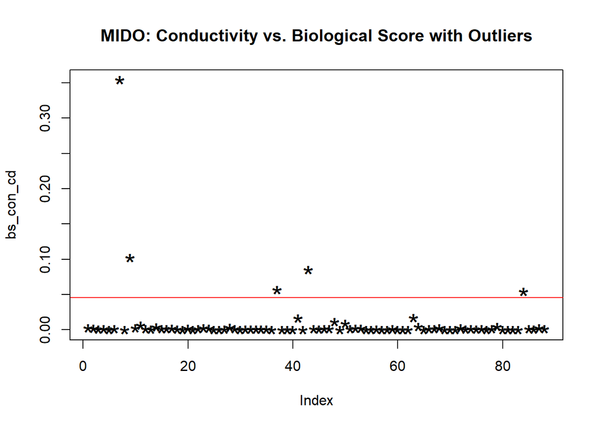

```r
#Creates a dataframe that stores the cook's distance analysis of influential data points.
bs_con_cd <- cooks.distance(bs_con_lm)
plot(bs_con_cd, pch="*", cex=2, main="MIDO: Conductivity vs. Biological Score with Outliers")
abline(h = 4/sample_size_MIDO, col="red")
```

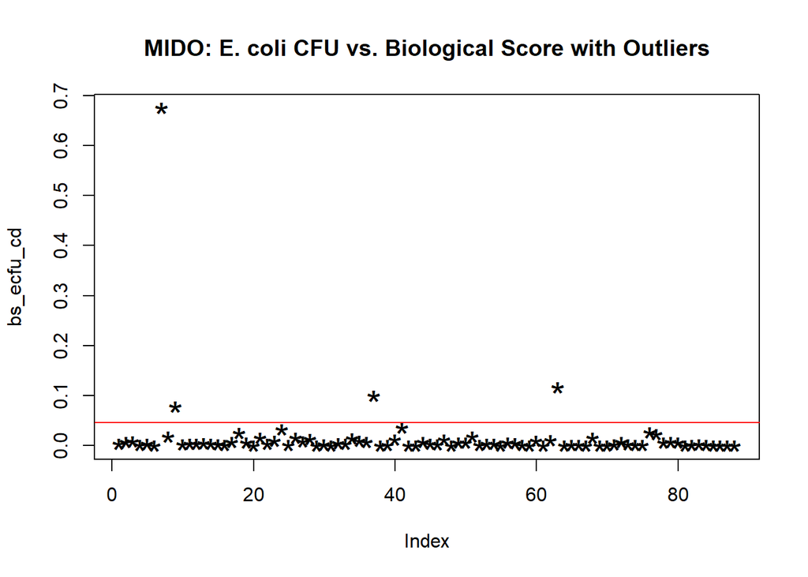

```r
bs_ecfu_cd <- cooks.distance(bs_ecfu_lm)
plot(bs_ecfu_cd, pch="*", cex=2, main="MIDO: E. coli CFU vs. Biological Score with Outliers")
abline(h = 4/sample_size_MIDO, col="red")
```

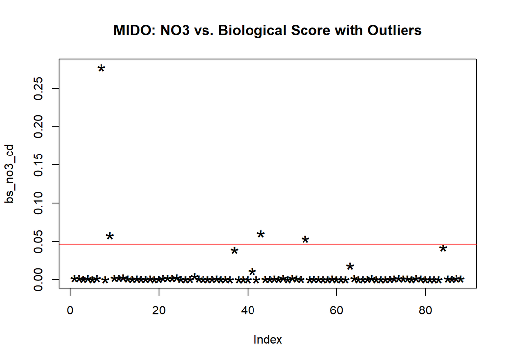

```r
bs_no3_cd <- cooks.distance(bs_no3_lm)
plot(bs_no3_cd, pch="*", cex=2, main="MIDO: NO3 vs. Biological Score with Outliers")
abline(h = 4/sample_size_MIDO, col="red")
```

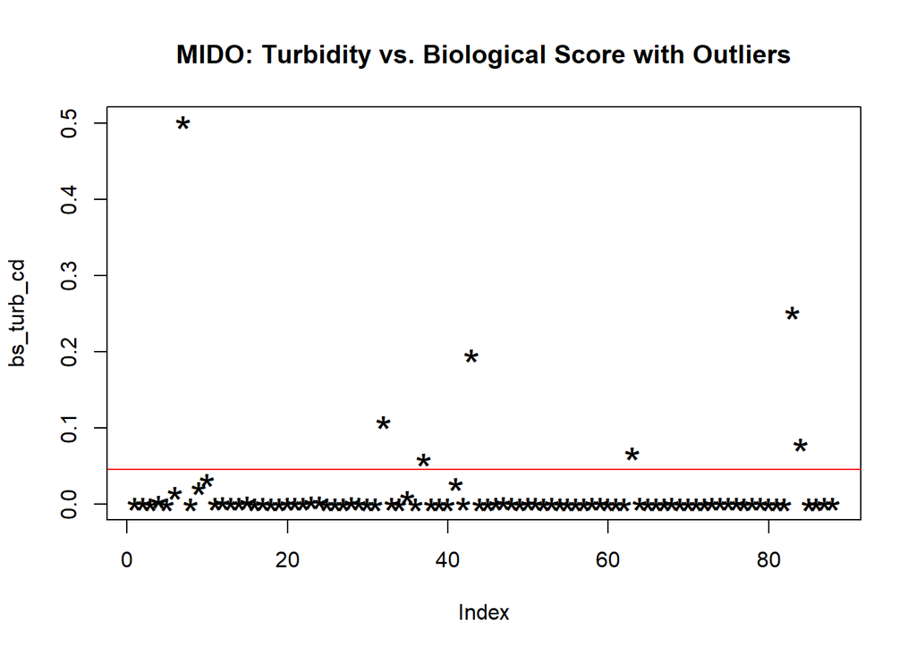

```r
bs_turb_cd <- cooks.distance(bs_turb_lm)
plot(bs_turb_cd, pch="*", cex=2, main="MIDO: Turbidity vs. Biological Score with Outliers")
abline(h = 4/sample_size_MIDO, col="red")
```

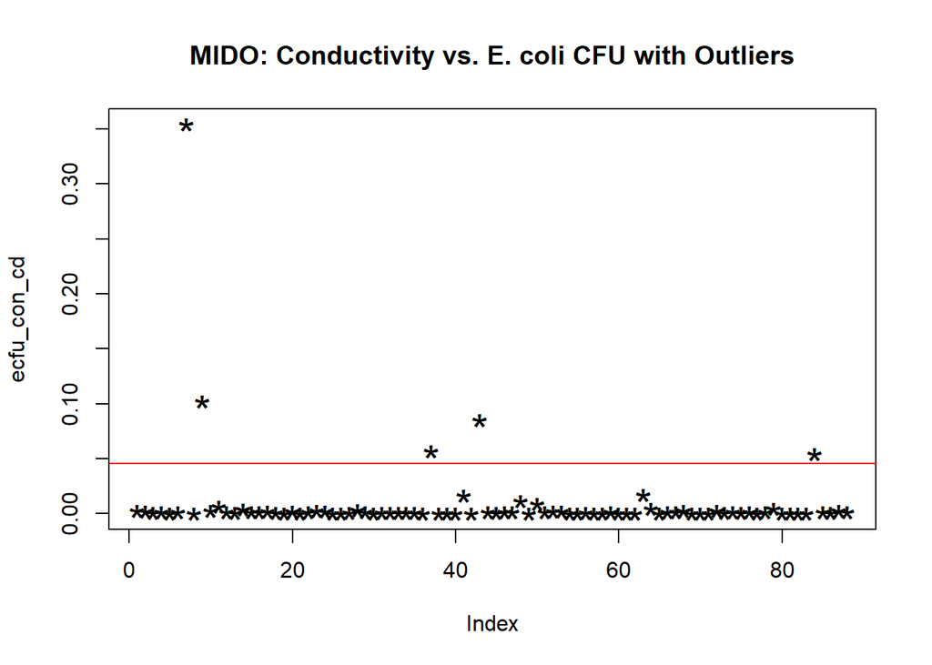

```r
#Creates a dataframe that stores the cook's distance analysis of influential data points.
ecfu_con_cd <- cooks.distance(ecfu_con_lm)
plot(ecfu_con_cd, pch="*", cex=2, main="MIDO: Conductivity vs. E. coli CFU with Outliers")
abline(h = 4/sample_size_MIDO, col="red")
```

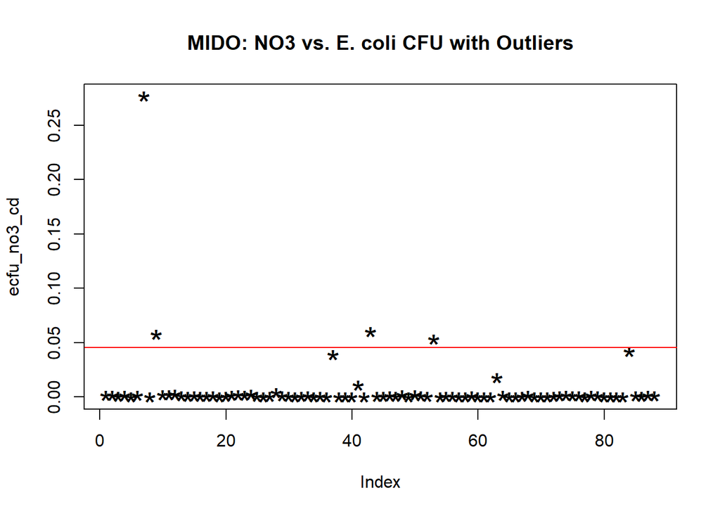

```r
ecfu_no3_cd <- cooks.distance(ecfu_no3_lm)
plot(ecfu_no3_cd, pch="*", cex=2, main="MIDO: NO3 vs. E. coli CFU with Outliers")
abline(h = 4/sample_size_MIDO, col="red")
```

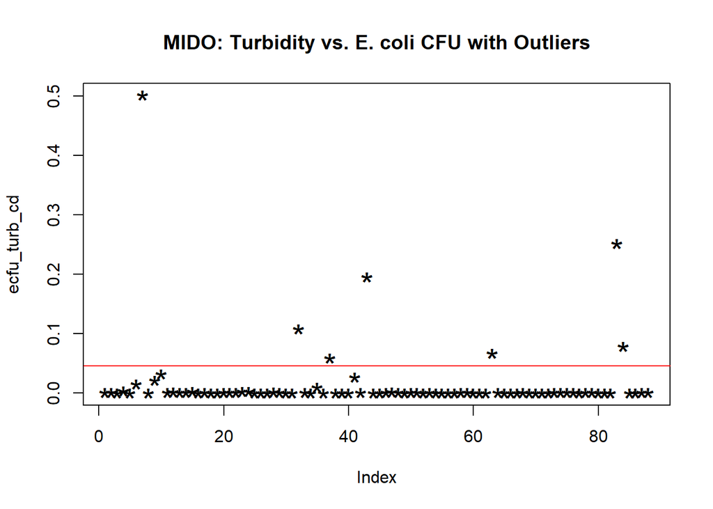

```r
ecfu_turb_cd <- cooks.distance(ecfu_turb_lm)
plot(ecfu_turb_cd, pch="*", cex=2, main="MIDO: Turbidity vs. E. coli CFU with Outliers")
abline(h = 4/sample_size_MIDO, col="red")
```

#### NORO

*Outcome: Biological Score*

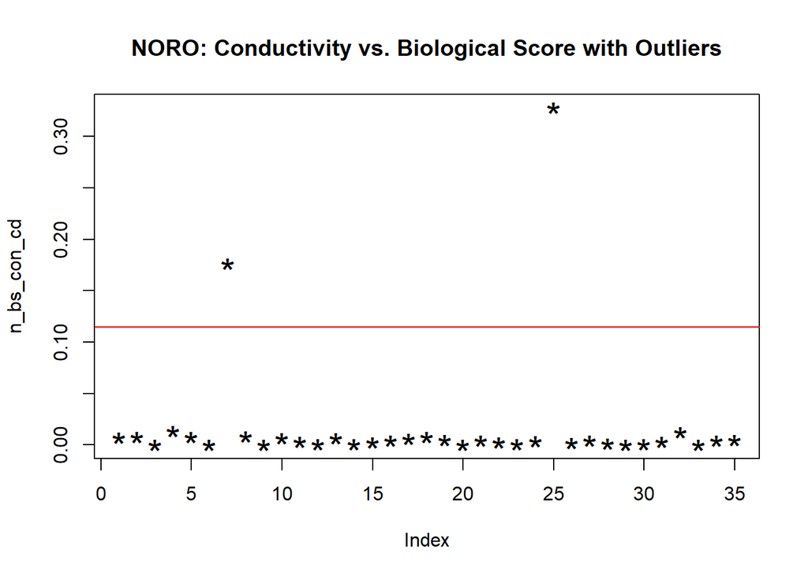

```r
#Creates a dataframe that stores the cook's distance analysis of influential data points.
n_bs_con_cd <- cooks.distance(n_bs_con_lm)
plot(n_bs_con_cd, pch="*", cex=2, main="NORO: Conductivity vs. Biological Score with Outliers")
abline(h = 4/sample_size_NORO, col="red")
```

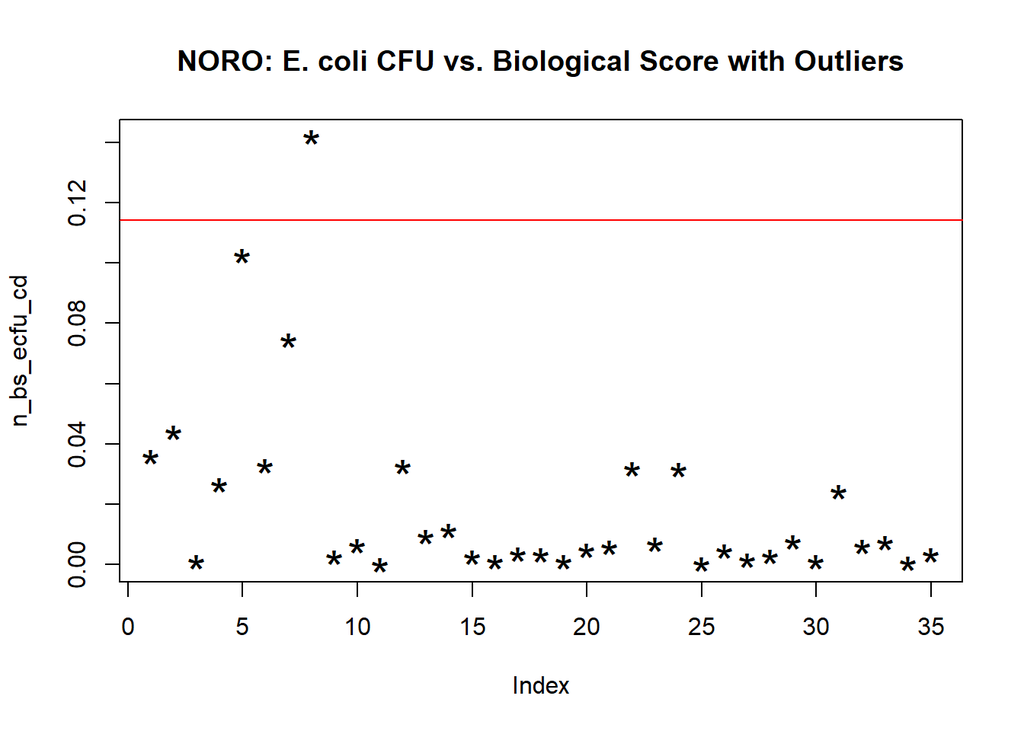

```r
n_bs_ecfu_cd <- cooks.distance(n_bs_ecfu_lm)
plot(n_bs_ecfu_cd, pch="*", cex=2, main="NORO: E. coli CFU vs. Biological Score with Outliers")
abline(h = 4/sample_size_NORO, col="red")
```

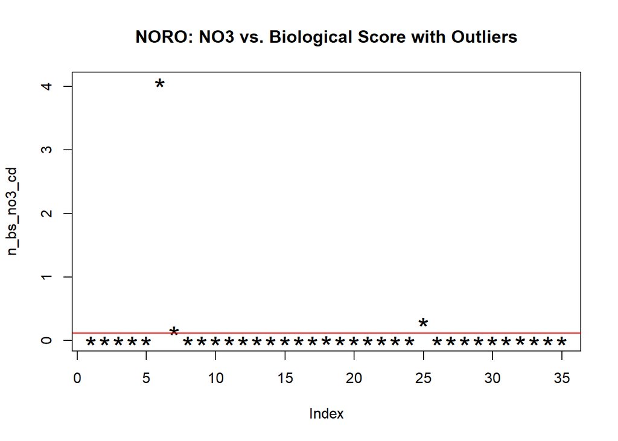

```r
n_bs_no3_cd <- cooks.distance(n_bs_no3_lm)
plot(n_bs_no3_cd, pch="*", cex=2, main="NORO: NO3 vs. Biological Score with Outliers")
abline(h = 4/sample_size_NORO, col="red")
```

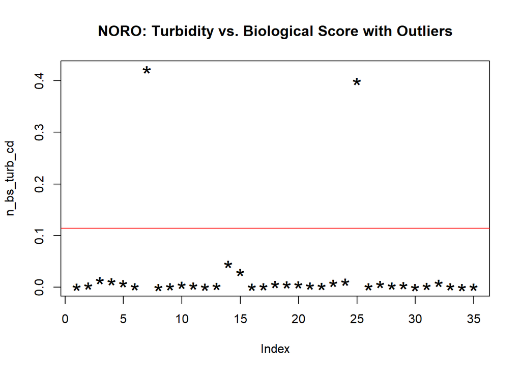

```r
n_bs_turb_cd <- cooks.distance(n_bs_turb_lm)
plot(n_bs_turb_cd, pch="*", cex=2, main="NORO: Turbidity vs. Biological Score with Outliers")
abline(h = 4/sample_size_NORO, col="red")
```

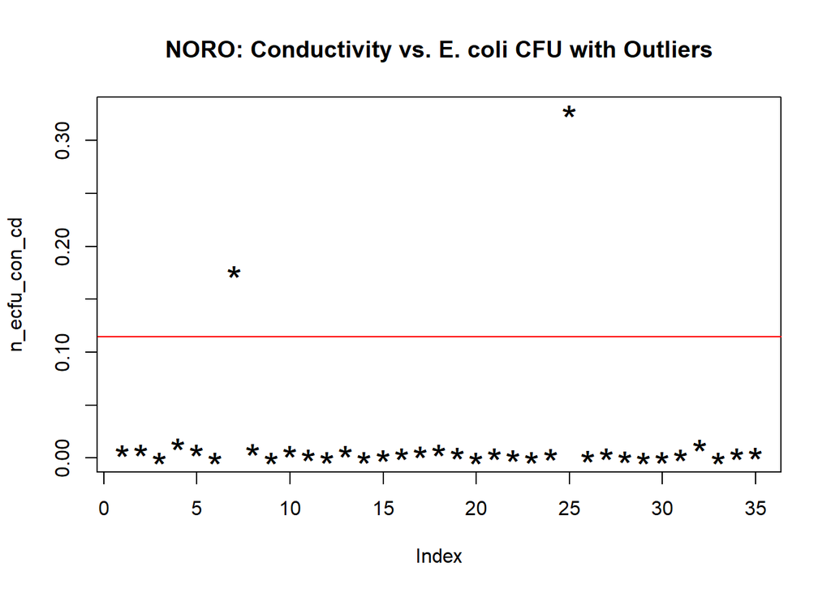

```r
#Creates a dataframe that stores the cook's distance analysis of influential data points.
n_ecfu_con_cd <- cooks.distance(n_ecfu_con_lm)
plot(n_ecfu_con_cd, pch="*", cex=2, main="NORO: Conductivity vs. E. coli CFU with Outliers")
abline(h = 4/sample_size_NORO, col="red")
```

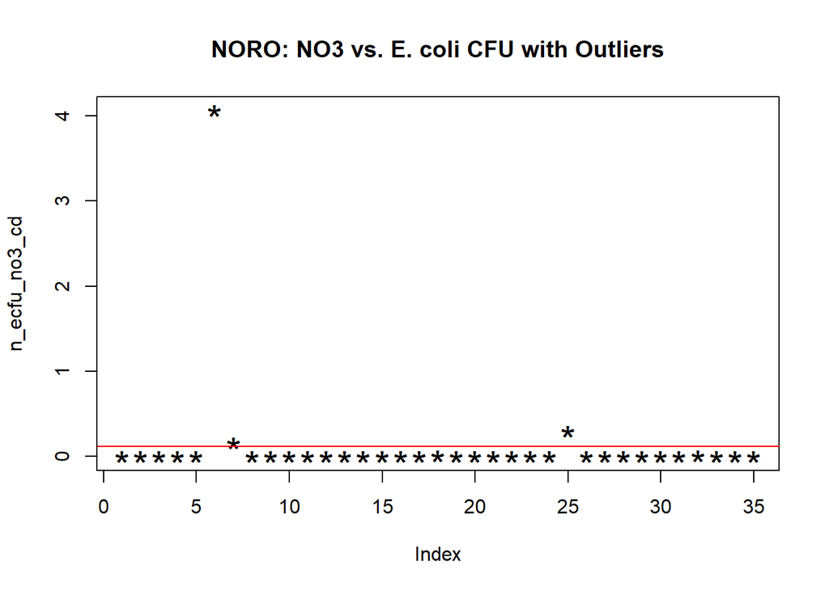

```r
n_ecfu_no3_cd <- cooks.distance(n_ecfu_no3_lm)
plot(n_ecfu_no3_cd, pch="*", cex=2, main="NORO: NO3 vs. E. coli CFU with Outliers")
abline(h = 4/sample_size_NORO, col="red")
```

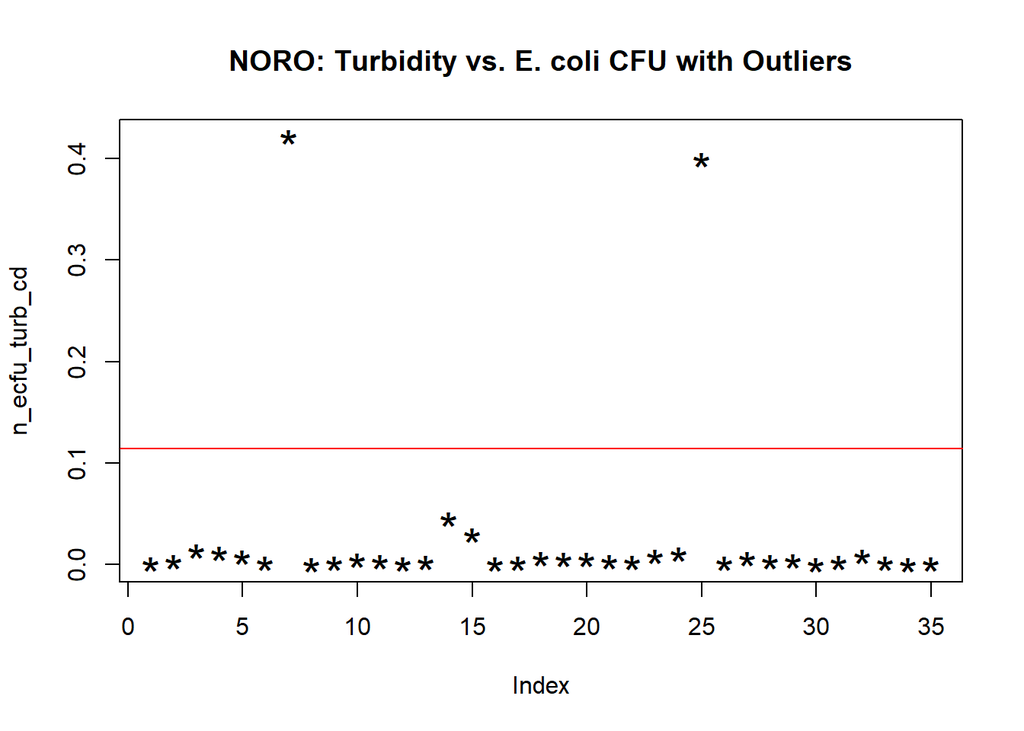

```r
n_ecfu_turb_cd <- cooks.distance(n_ecfu_turb_lm)
plot(n_ecfu_turb_cd, pch="*", cex=2, main="NORO: Turbidity vs. E. coli CFU with Outliers")
abline(h = 4/sample_size_NORO, col="red")
```

#### BICO

*Outcome: Biological Score*

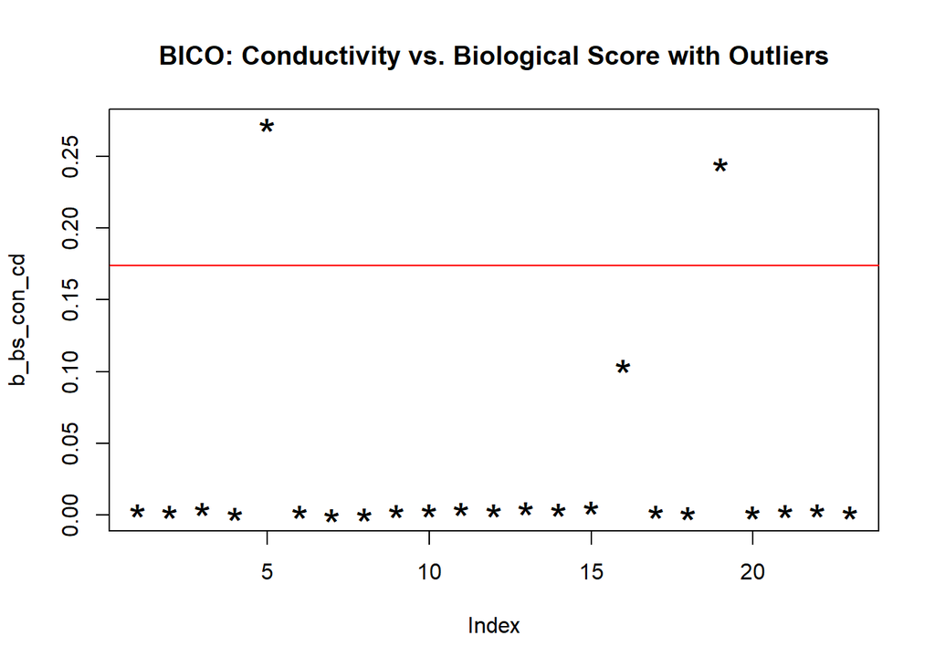

```r
#Creates a dataframe that stores the cook's distance analysis of influential data points.
b_bs_con_cd <- cooks.distance(b_bs_con_lm)
plot(b_bs_con_cd, pch="*", cex=2, main="BICO: Conductivity vs. Biological Score with Outliers")
abline(h = 4/sample_size_BICO, col="red")
```

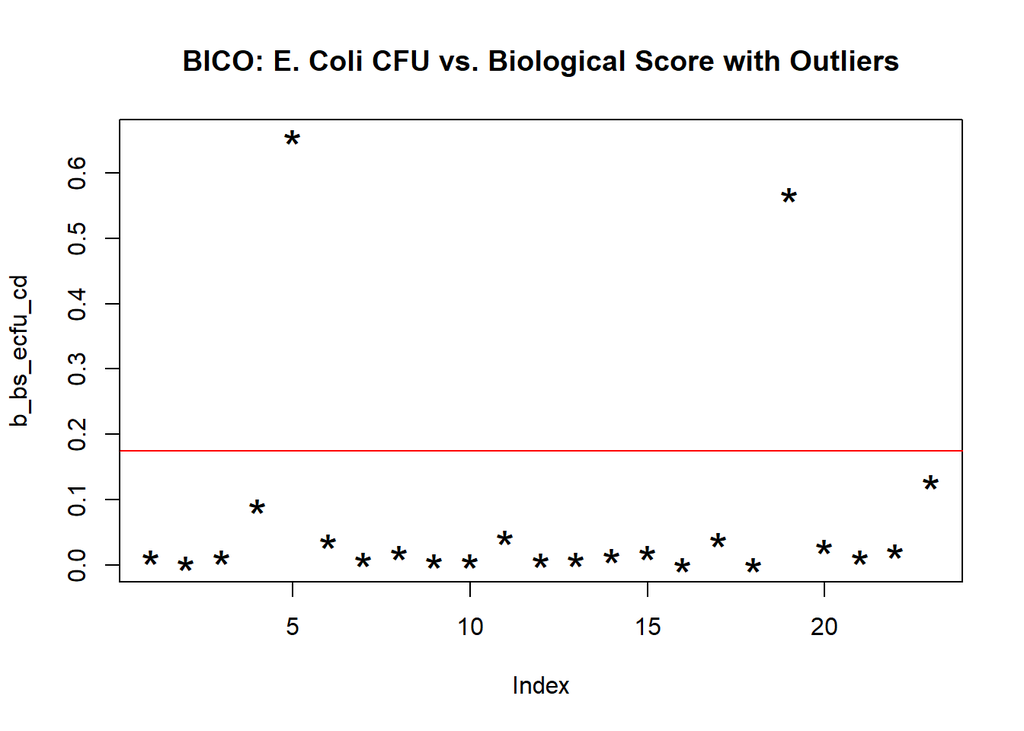

```r
b_bs_ecfu_cd <- cooks.distance(b_bs_ecfu_lm)
plot(b_bs_ecfu_cd, pch="*", cex=2, main="BICO: E. Coli CFU vs. Biological Score with Outliers")
abline(h = 4/sample_size_BICO, col="red")
```

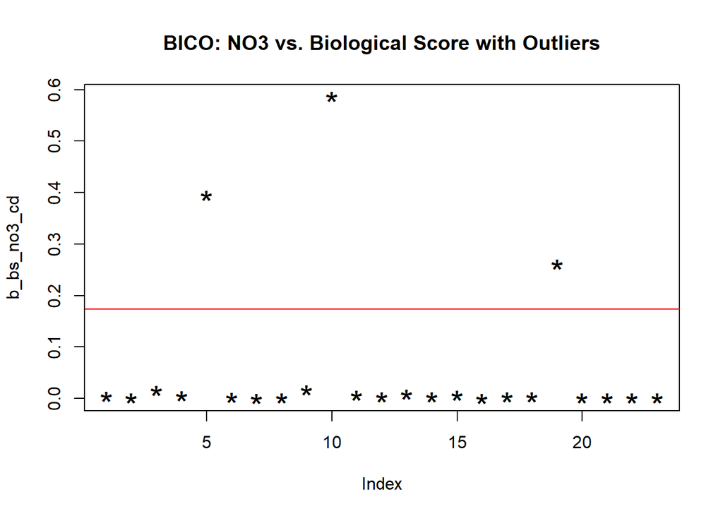

```r
b_bs_no3_cd <- cooks.distance(b_bs_no3_lm)
plot(b_bs_no3_cd, pch="*", cex=2, main="BICO: NO3 vs. Biological Score with Outliers")
abline(h = 4/sample_size_BICO, col="red")
```

[figure not shown]

```r
b_bs_turb_cd <- cooks.distance(bs_turb_lm)
plot(b_bs_turb_cd, pch="*", cex=2, main="BICO: Turbidity vs. Biological Score with Outliers")
abline(h = 4/sample_size_BICO, col="red")
```

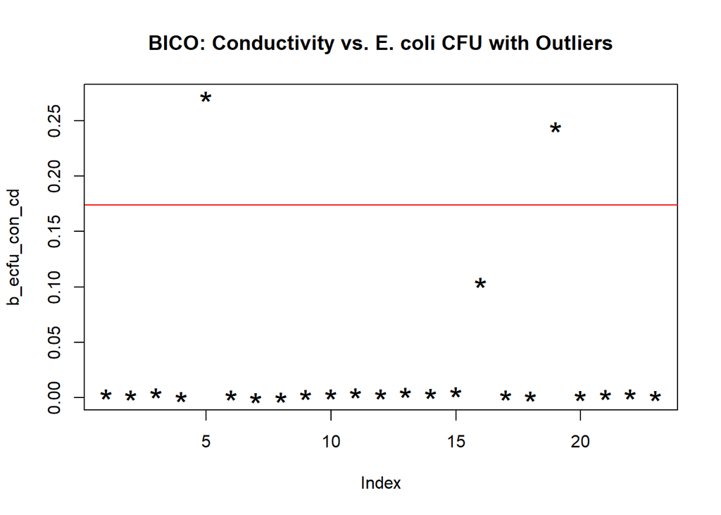

```r
#Creates a dataframe that stores the cook's distance analysis of influential data points.
b_ecfu_con_cd <- cooks.distance(b_ecfu_con_lm)
plot(b_ecfu_con_cd, pch="*", cex=2, main="BICO: Conductivity vs. E. coli CFU with Outliers")
abline(h = 4/sample_size_BICO, col="red")
```

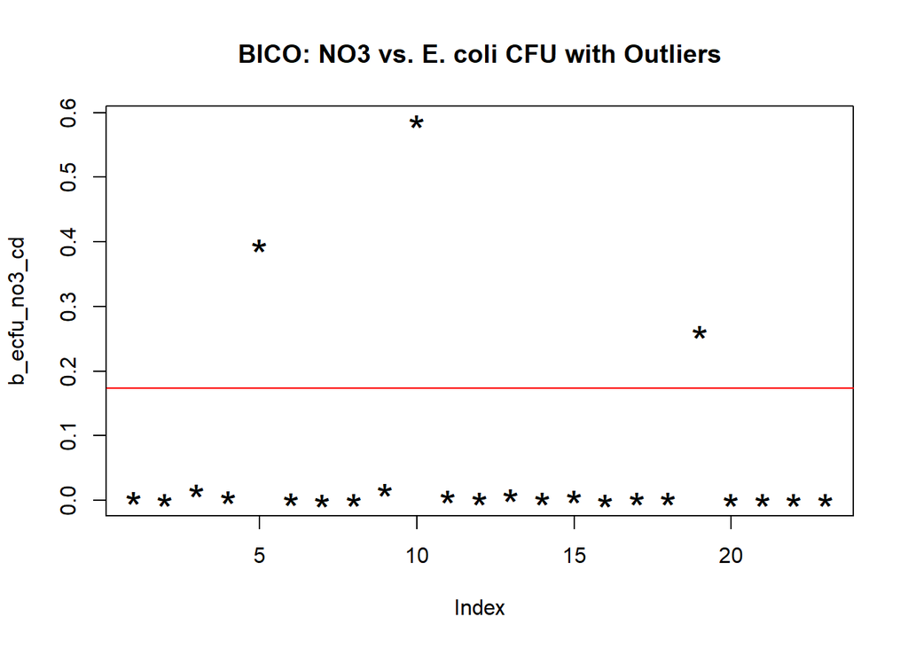

```r
b_ecfu_no3_cd <- cooks.distance(b_ecfu_no3_lm)
plot(b_ecfu_no3_cd, pch="*", cex=2, main="BICO: NO3 vs. E. coli CFU with Outliers")
abline(h = 4/sample_size_BICO, col="red")
```

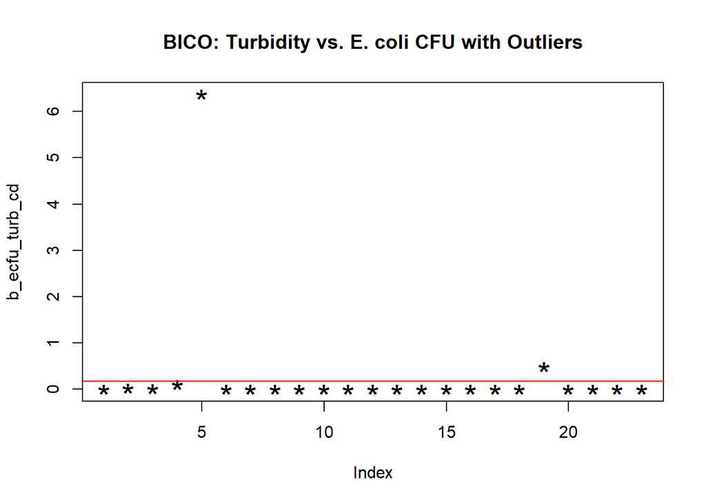

```r
b_ecfu_turb_cd <- cooks.distance(b_ecfu_turb_lm)
plot(b_ecfu_turb_cd, pch="*", cex=2, main="BICO: Turbidity vs. E. coli CFU with Outliers")
abline(h = 4/sample_size_BICO, col="red")
```

# Part 2: Linear Model Fit Assessment for MIDO Data

*Moving forward, I want to focus in on just the MIDO dataset. As you can tell, working with many variables in three different data sets can be quite cumbersome to read through. For ease of interpretation, the MIDO data set will serve as the data frame where I test how robust the linear fit models actually are for the data. MIDO is the only data set large enough that when we split the data set into a “test” and “train” data set, I actually have confidence in the resulting model fit analysis. For comparison, MIDO has an n = 88; NORO has an n = 35; and BICO has an n = 23. The only thing we are missing by dropping the other sites is assessing site-by-site comparison, which I am choosing not to focus on anyway.*

#### Splitting MIDO Data

*As discussed above, we need to split the MIDO data into a test and train data set. We do this to see if we get approximately the same linear relationship between the larger (75% of MIDO) train data and the smaller (25% of MIDO) test data.*

```r
#Split the data with 1:4 ratio.
data_split <- initial_split(MIDO, prop = 3/4)

# Create data frames for the two sets:
train_data <- training(data_split)
test_data  <- testing(data_split)
```

*Create a recipe for each linear model relationship in the MIDO dataframe.*

```r
Recipe_bs_con <- recipe(biological_score ~ conductivity.uscm, data = MIDO)
Recipe_bs_ecfu <- recipe(biological_score ~ e.coli.cfu, data = MIDO)
Recipe_bs_no3 <- recipe(biological_score ~ no3.mgL, data = MIDO)
Recipe_bs_turb <- recipe(biological_score ~ turbidity.ntu, data = MIDO)
Recipe_ecfu_con <- recipe(e.coli.cfu ~ e.coli.cfu, data = MIDO)
Recipe_ecfu_no3 <- recipe(e.coli.cfu ~ no3.mgL, data = MIDO)
Recipe_ecfu_turb <- recipe(e.coli.cfu ~ turbidity.ntu, data = MIDO)
```

*With our seven linear model recipes created, we will define of linear regression model pipe.*

```r
linear_mod <- linear_reg() %>%
  set_engine("lm") %>%
  set_mode("regression")
```

*Next, create a workflow that adds our seven recipes and model together.*

```r
#Biological Score and Conductivity
bs_con_wflow <-
  workflow() %>%
  add_model(linear_mod) %>%
  add_recipe(Recipe_bs_con)

#Biological Score and E. coli(cfu)
bs_ecfu_wflow <-
  workflow() %>%
  add_model(linear_mod) %>%
  add_recipe(Recipe_bs_ecfu)

#Biological Score and NO3
bs_no3_wflow <-
  workflow() %>%
  add_model(linear_mod) %>%
  add_recipe(Recipe_bs_no3)

#Biological Score and Turbidity
bs_turb_wflow <-
  workflow() %>%
  add_model(linear_mod) %>%
  add_recipe(Recipe_bs_turb)

#E. Coli (cfu) and Conductivity
ecfu_con_wflow <-
  workflow() %>%
  add_model(linear_mod) %>%
  add_recipe(Recipe_ecfu_con)

#E. Coli (cfu) and NO3
ECFU_no3_wflow <-
  workflow() %>%
  add_model(linear_mod) %>%
  add_recipe(Recipe_ecfu_no3)

#E. Coli (cfu) and Turbidity
ecfu_turb_wflow <-
  workflow() %>%
  add_model(linear_mod) %>%
  add_recipe(Recipe_ecfu_turb)
```

## Modeling Train Data Predictions Using Workflows

*Using the workflow above, lets now fit each pf the seven stream health indicator linear models to the train data set.*

*Defining a command that runs model fitting to each of the seven models*

```r
bs_con_fit <-
  bs_con_wflow %>%
  fit(data = train_data)

bs_ecfu_fit <-
  bs_ecfu_wflow %>%
  fit(data = train_data)

bs_no3_fit <-
  bs_no3_wflow %>%
  fit(data = train_data)

bs_turb_fit <-
  bs_turb_wflow %>%
  fit(data = train_data)

ecfu_con_fit <-
  ecfu_con_wflow %>%
  fit(data = train_data)

ecfu_no3_fit <-
  ECFU_no3_wflow %>%
  fit(data = train_data)

ecfu_turb_fit <-
  ecfu_turb_wflow %>%
  fit(data = train_data)
```

*Pull linear regression fit models using parsnip().*

```r
bs_con_fit %>%
  extract_fit_parsnip() %>%
  tidy()
```

```
## # A tibble: 2 x 5
##   term              estimate std.error statistic  p.value
##   <chr>                <dbl>     <dbl>     <dbl>    <dbl>
## 1 (Intercept)        19.6       1.89      10.4   2.34e-15
## 2 conductivity.uscm  -0.0140    0.0233    -0.600 5.50e- 1
```

```r
bs_ecfu_fit %>%
  extract_fit_parsnip() %>%
  tidy()
```

```
## # A tibble: 2 x 5
##   term         estimate std.error statistic  p.value
##   <chr>           <dbl>     <dbl>     <dbl>    <dbl>
## 1 (Intercept) 18.7       0.826       22.7   2.72e-32
## 2 e.coli.cfu  -0.000312  0.000750    -0.416 6.79e- 1
```

```r
bs_no3_fit %>%
  extract_fit_parsnip() %>%
  tidy()
```

```
## # A tibble: 2 x 5
##   term        estimate std.error statistic  p.value
##   <chr>          <dbl>     <dbl>     <dbl>    <dbl>
## 1 (Intercept)   18.3       0.782    23.4   4.23e-33
## 2 no3.mgL        0.114     0.131     0.866 3.90e- 1
```

```r
bs_turb_fit %>%
  extract_fit_parsnip() %>%
  tidy()
```

```
## # A tibble: 2 x 5
##   term          estimate std.error statistic  p.value
##   <chr>            <dbl>     <dbl>     <dbl>    <dbl>
## 1 (Intercept)    17.8       1.05       16.9  2.56e-25
## 2 turbidity.ntu   0.0865    0.0839      1.03 3.06e- 1
```

```r
ecfu_con_fit %>%
  extract_fit_parsnip() %>%
  tidy()
```

```
## # A tibble: 1 x 5
##   term        estimate std.error statistic   p.value
##   <chr>          <dbl>     <dbl>     <dbl>     <dbl>
## 1 (Intercept)     513.      121.      4.25 0.0000709
```

```r
ecfu_no3_fit %>%
  extract_fit_parsnip() %>%
  tidy()
```

```
## # A tibble: 2 x 5
##   term        estimate std.error statistic  p.value
##   <chr>          <dbl>     <dbl>     <dbl>    <dbl>
## 1 (Intercept)   530.       131.      4.05  0.000141
## 2 no3.mgL        -7.57      22.0    -0.345 0.732
```

```r
ecfu_turb_fit %>%
  extract_fit_parsnip() %>%
  tidy()
```

```
## # A tibble: 2 x 5
##   term          estimate std.error statistic p.value
##   <chr>            <dbl>     <dbl>     <dbl>   <dbl>
## 1 (Intercept)      287.      172.       1.67  0.100
## 2 turbidity.ntu     25.0      13.7      1.82  0.0734
```

#### Using Workflows to Make Predictions in the train data set.

*This is important because we are basically going to try and recreate the actual MIDO data set using the test and trained data and our linear models. We will eventually compare the test data predictions with the train data predictions to assess if our model is actually a good estimator of the relationships between stream health indicators. Additionally, this prediction step allows us to “artificially” create a larger n for our data, allowing fit to be assessed more accurately. This will be done using the augment() function to make predicted outcomes in the test and train data.*

```r
bs_con_aug <-
  augment(bs_con_fit, train_data)

bs_ecfu_aug <-
  augment(bs_ecfu_fit, train_data)

bs_no3_aug <-
  augment(bs_no3_fit, train_data)

bs_turb_aug <-
  augment(bs_turb_fit, train_data)

ecfu_con_aug <-
  augment(ecfu_con_fit, train_data)

ecfu_no3_aug <-
  augment(ecfu_no3_fit, train_data)

ecfu_turb_aug <-
  augment(ecfu_turb_fit, train_data)
```

#### Using Root Mean Squared Error (RMSE) to Assess Model Fit.

```r
bs_con_aug %>%
  rmse(truth = biological_score, .pred)
```

```
## # A tibble: 1 x 3
##   .metric .estimator .estimate
##   <chr>   <chr>          <dbl>
## 1 rmse    standard        5.84
```

```r
bs_ecfu_aug %>%
  rmse(truth = biological_score, .pred)
```

```
## # A tibble: 1 x 3
##   .metric .estimator .estimate
##   <chr>   <chr>          <dbl>
## 1 rmse    standard        5.85
```

```r
bs_no3_aug %>%
  rmse(truth = biological_score, .pred)
```

```
## # A tibble: 1 x 3
##   .metric .estimator .estimate
##   <chr>   <chr>          <dbl>
## 1 rmse    standard        5.82
```

```r
bs_turb_aug %>%
  rmse(truth = biological_score, .pred)
```

```
## # A tibble: 1 x 3
##   .metric .estimator .estimate
##   <chr>   <chr>          <dbl>
## 1 rmse    standard        5.81
```

```r
ecfu_con_aug %>%
  rmse(truth = e.coli.cfu, .pred)
```

```
## # A tibble: 1 x 3
##   .metric .estimator .estimate
##   <chr>   <chr>          <dbl>
## 1 rmse    standard        974.
```

```r
ecfu_no3_aug %>%
  rmse(truth = e.coli.cfu, .pred)
```

```
## # A tibble: 1 x 3
##   .metric .estimator .estimate
##   <chr>   <chr>          <dbl>
## 1 rmse    standard        973.
```

```r
ecfu_turb_aug %>%
  rmse(truth = e.coli.cfu, .pred)
```

```
## # A tibble: 1 x 3
##   .metric .estimator .estimate
##   <chr>   <chr>          <dbl>
## 1 rmse    standard        950.
```

## Modeling Test Data Predictions Using Workflows

*Using the workflow above, lets now fit each pf the seven stream health indicator linear models to the test data set.*

*Defining a command that runs model fitting to each of the seven models*

```r
bs_con_fit_test <-
  bs_con_wflow %>%
  fit(data = test_data)

bs_ecfu_fit_test <-
  bs_ecfu_wflow %>%
  fit(data = test_data)

bs_no3_fit_test <-
  bs_no3_wflow %>%
  fit(data = test_data)

bs_turb_fit_test <-
  bs_turb_wflow %>%
  fit(data = test_data)

ecfu_con_fit_test <-
  ecfu_con_wflow %>%
  fit(data = test_data)

ecfu_no3_fit_test <-
  ECFU_no3_wflow %>%
  fit(data = test_data)

ecfu_turb_fit_test <-
  ecfu_turb_wflow %>%
  fit(data = test_data)
```

*Pull linear regression fit models using parsnip().*

```r
bs_con_fit_test %>%
  extract_fit_parsnip() %>%
  tidy()
```

```
## # A tibble: 2 x 5
##   term              estimate std.error statistic p.value
##   <chr>                <dbl>     <dbl>     <dbl>   <dbl>
## 1 (Intercept)        17.8       6.25       2.85  0.00983
## 2 conductivity.uscm  -0.0348    0.0802    -0.434 0.669
```

```r
bs_ecfu_fit_test %>%
  extract_fit_parsnip() %>%
  tidy()
```

```
## # A tibble: 2 x 5
##   term        estimate std.error statistic     p.value
##   <chr>          <dbl>     <dbl>     <dbl>       <dbl>
## 1 (Intercept) 16.7       2.26         7.37 0.000000401
## 2 e.coli.cfu  -0.00267   0.00257     -1.04 0.310
```

```r
bs_no3_fit_test %>%
  extract_fit_parsnip() %>%
  tidy()
```

```
## # A tibble: 2 x 5
##   term        estimate std.error statistic    p.value
##   <chr>          <dbl>     <dbl>     <dbl>      <dbl>
## 1 (Intercept)   13.7       2.27       6.03 0.00000674
## 2 no3.mgL        0.886     0.836      1.06 0.302
```

```r
bs_turb_fit_test %>%
  extract_fit_parsnip() %>%
  tidy()
```

```
## # A tibble: 2 x 5
##   term          estimate std.error statistic    p.value
##   <chr>            <dbl>     <dbl>     <dbl>      <dbl>
## 1 (Intercept)     13.6       2.28       5.96 0.00000797
## 2 turbidity.ntu    0.166     0.147      1.12 0.275
```

```r
ecfu_con_fit_test %>%
  extract_fit_parsnip() %>%
  tidy()
```

```
## # A tibble: 1 x 5
##   term        estimate std.error statistic p.value
##   <chr>          <dbl>     <dbl>     <dbl>   <dbl>
## 1 (Intercept)     549.      151.      3.64 0.00153
```

```r
ecfu_no3_fit_test %>%
  extract_fit_parsnip() %>%
  tidy()
```

```
## # A tibble: 2 x 5
##   term        estimate std.error statistic p.value
##   <chr>          <dbl>     <dbl>     <dbl>   <dbl>
## 1 (Intercept)    669.      194.      3.45  0.00251
## 2 no3.mgL        -70.4      71.2    -0.989 0.334
```

```r
ecfu_turb_fit_test %>%
  extract_fit_parsnip() %>%
  tidy()
```

```
## # A tibble: 2 x 5
##   term          estimate std.error statistic p.value
##   <chr>            <dbl>     <dbl>     <dbl>   <dbl>
## 1 (Intercept)     465.       198.      2.35   0.0290
## 2 turbidity.ntu     8.54      12.8     0.669  0.511
```

#### Using Workflows to Make Predictions in the test data set.

*This is important because we are basically going to try and recreate the actual MIDO data set using the test and trained data and our linear models. This prediction step allows us to “artificially” create a larger n for our data, allowing fit to be assessed more accurately for data predicted from split data. This will be done using the augment() function to make predicted outcomes in the test and train data.*

```r
bs_con_aug_test <-
  augment(bs_con_fit, test_data)

bs_ecfu_aug_test <-
  augment(bs_ecfu_fit, test_data)

bs_no3_aug_test <-
  augment(bs_no3_fit, test_data)

bs_turb_aug_test <-
  augment(bs_turb_fit, test_data)

ecfu_con_aug_test <-
  augment(ecfu_con_fit, test_data)

ecfu_no3_aug_test <-
  augment(ecfu_no3_fit, test_data)

ecfu_turb_aug_test <-
  augment(ecfu_turb_fit, test_data)
```

#### Using Root Mean Squared Error (RMSE) to Assess Model Fit.

```r
bs_con_aug_test %>%
  rmse(truth = biological_score, .pred)
```

```
## # A tibble: 1 x 3
##   .metric .estimator .estimate
##   <chr>   <chr>          <dbl>
## 1 rmse    standard        8.78
```

```r
bs_ecfu_aug_test %>%
  rmse(truth = biological_score, .pred)
```

```
## # A tibble: 1 x 3
##   .metric .estimator .estimate
##   <chr>   <chr>          <dbl>
## 1 rmse    standard        8.76
```

```r
bs_no3_aug_test %>%
  rmse(truth = biological_score, .pred)
```

```
## # A tibble: 1 x 3
##   .metric .estimator .estimate
##   <chr>   <chr>          <dbl>
## 1 rmse    standard        8.73
```

```r
bs_turb_aug_test %>%
  rmse(truth = biological_score, .pred)
```

```
## # A tibble: 1 x 3
##   .metric .estimator .estimate
##   <chr>   <chr>          <dbl>
## 1 rmse    standard        8.65
```

```r
ecfu_con_aug_test %>%
  rmse(truth = e.coli.cfu, .pred)
```

```
## # A tibble: 1 x 3
##   .metric .estimator .estimate
##   <chr>   <chr>          <dbl>
## 1 rmse    standard        692.
```

```r
ecfu_no3_aug_test %>%
  rmse(truth = e.coli.cfu, .pred)
```

```
## # A tibble: 1 x 3
##   .metric .estimator .estimate
##   <chr>   <chr>          <dbl>
## 1 rmse    standard        688.
```

```r
ecfu_turb_aug_test %>%
  rmse(truth = e.coli.cfu, .pred)
```

```
## # A tibble: 1 x 3
##   .metric .estimator .estimate
##   <chr>   <chr>          <dbl>
## 1 rmse    standard        711.
```

```r
#Create a location and save linear model for E. coli (cfu) in the MIDO train data.
MIDO_ECFU_Con_fit_location <- here::here("results","MIDO_ECFU_Con_fit.rds")
saveRDS(ecfu_con_fit, file = MIDO_ECFU_Con_fit_location)

#Create a location and save linear model for E. coli (cfu) in the MIDO test data.
MIDO_ECFU_Con_fit_test_location <- here::here("results","MIDO_ECFU_Con_fit_test.rds")
saveRDS(ecfu_con_fit_test, file = MIDO_ECFU_Con_fit_test_location)
```

```r
#Create a location and save RMSE for E. coli (cfu) in the MIDO train data.
MIDO_ECFU_Con_RMSE_location <- here::here("results","MIDO_ECFU_Con_RMSE.rds")
saveRDS(ecfu_con_aug, file = MIDO_ECFU_Con_RMSE_location)

#Create a location and save linear RMSE for E. coli (cfu) in the MIDO test data.
MIDO_ECFU_Con_RMSE_test_location <- here::here("results","MIDO_ECFU_Con_RMSE_test.rds")
saveRDS(ecfu_con_aug_test, file = MIDO_ECFU_Con_RMSE_test_location)
```

# Part 3: LASSO Modeling for Ideal Combination of Stream Health Indicators to Predict Biological SCore and E. Coli Colony Forming Units in MIDO Data.

# Biological Score

## Data Set Up:

*Take ID and time variables out of MIDO Data frame. This will help reduce errors when we try to run the Model.*

```r
MIDO_LASSO <- MIDO %>%
  select(-"WSID", -"stream_ID", -"month", -"year", -"day", -"pH")
```

*log transform E. coli data to fix bias in E. coli data*

```r
MIDO_LASSO <- MIDO_LASSO %>%
  mutate(e.coli.cfu = log10(MIDO_LASSO$e.coli.cfu))
```

*Set seed: This sets a random number generator with initial (pseudo)random values set as “123”. We will need a series of random numbers created for our machine learning analysis.*

```r
#Set random number generator.
set.seed(123)
```

## Null Model For MIDO Data

```r
#Create folds for LASSO Cross Validation.
fold_BS <- vfold_cv(MIDO_LASSO, v = 5, repeats = 5, strata = biological_score)
```

*Creating the recipe for Biological Score vs all predictors*

```r
BS.recipe <-
  recipe(biological_score ~ ., data = MIDO_LASSO) %>%
  step_zv(all_predictors()) %>%
  step_normalize(all_predictors())

BS.recipe
```

```
## Recipe
##
## Inputs:
##
##       role #variables
##    outcome          1
##  predictor          4
##
## Operations:
##
## Zero variance filter on all_predictors()
## Centering and scaling for all_predictors()
```

*Setting linear regression model to assess relationship between Biological Score (outcome) and all other predictor variables.*

```r
lm_mod <- linear_reg() %>% set_engine("lm") %>% set_mode("regression")
```

*However, first we need to create our null model to test against.*

### Null Model:

*Creates null model recipe. When we call this term, it will indicate in our workflow that Biological Score will be predicted by a value of 1 (NULL).*

```r
Null_recipe_lm <- recipe(biological_score ~ 1, data = MIDO_LASSO)
```

*Creating the Workflow: this creates a set workflow for running a null linear regression model with biological score as the outcome.*

```r
null_wf <- workflow() %>% add_model(lm_mod) %>% add_recipe(Null_recipe_lm)
```

```r
null_lm <- fit_resamples(null_wf, resamples = fold_BS)
```

[output not shown]

[output not shown]

[output not shown]

[output not shown]

[output not shown]

[output not shown]

[output not shown]

[output not shown]

[output not shown]

[output not shown]

[output not shown]

[output not shown]

[output not shown]

[output not shown]

[output not shown]

[output not shown]

[output not shown]

[output not shown]

[output not shown]

[output not shown]

[output not shown]

[output not shown]

[output not shown]

[output not shown]

[output not shown]

*Calculate RMSE for the Null linear model.*

```r
Null_Met <- collect_metrics(null_lm)

Null_Met <- kable(Null_Met,
      caption = "Root Mean Squared Error and Standard Deviation for Biological Score Null Linear Model")

Null_Met
```

Root Mean Squared Error and Standard Deviation for Biological Score Null Linear Model

| .metric | .estimator | mean | n | std_err | .config |
| --- | --- | --- | --- | --- | --- |
| rmse | standard | 6.628388 | 25 | 0.1313342 | Preprocessor1_Model1 |
| rsq | standard | NaN | 0 | NA | Preprocessor1_Model1 |

*RMSE = 6.63, with a standard deviation of 0.13. This will serve as our check to test our models against latter on.*

## LASSO Model

*Specifying The Model: LASSO*

```r
lasso_mod <-
  linear_reg(penalty = tune(), mixture = 1) %>%
  set_engine("glmnet")
```

*Creating a Workflow: LASSO*

```r
lasso_wf <- workflow() %>%
  add_model(lasso_mod) %>%
  add_recipe(BS.recipe)
```

*Create Tuning Grid: LASSO*

```r
LASSO_grid <- grid_regular(penalty(), levels = 50)
```

*Cross Validation with tune_grid(): LASSO*

```r
lasso_resample <-
  lasso_wf %>%
  tune_grid(resamples = fold_BS,
            grid = LASSO_grid,
            control = control_grid(verbose = FALSE, save_pred = TRUE),
            metrics = metric_set(rmse))

lasso_resample %>%
  collect_metrics()
```

```
## # A tibble: 50 x 7
##     penalty .metric .estimator  mean     n std_err .config
##       <dbl> <chr>   <chr>      <dbl> <int>   <dbl> <chr>
##  1 1   e-10 rmse    standard    6.72    25   0.218 Preprocessor1_Model01
##  2 1.60e-10 rmse    standard    6.72    25   0.218 Preprocessor1_Model02
##  3 2.56e-10 rmse    standard    6.72    25   0.218 Preprocessor1_Model03
##  4 4.09e-10 rmse    standard    6.72    25   0.218 Preprocessor1_Model04
##  5 6.55e-10 rmse    standard    6.72    25   0.218 Preprocessor1_Model05
##  6 1.05e- 9 rmse    standard    6.72    25   0.218 Preprocessor1_Model06
##  7 1.68e- 9 rmse    standard    6.72    25   0.218 Preprocessor1_Model07
##  8 2.68e- 9 rmse    standard    6.72    25   0.218 Preprocessor1_Model08
##  9 4.29e- 9 rmse    standard    6.72    25   0.218 Preprocessor1_Model09
## 10 6.87e- 9 rmse    standard    6.72    25   0.218 Preprocessor1_Model10
## # ... with 40 more rows
```

*Plot model performance using autoplot()*

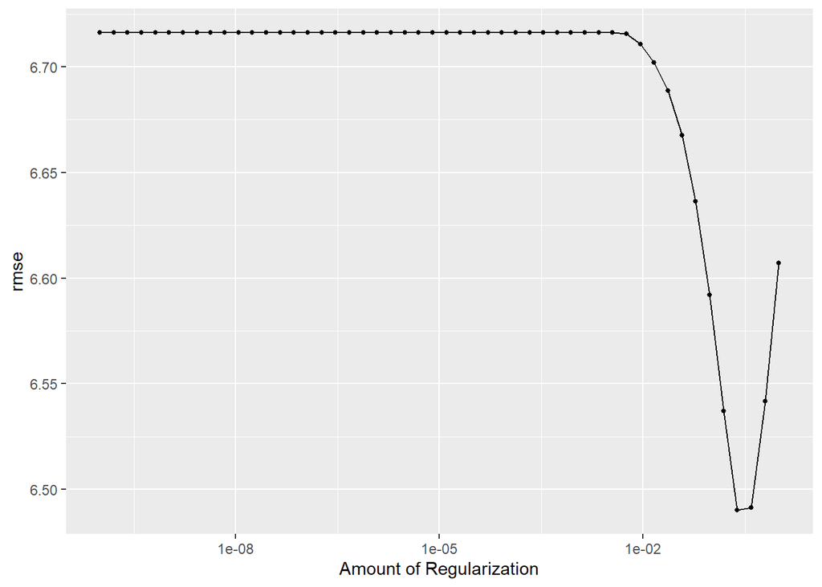

```r
#Plot of MIDO data LASSO model performance
lasso_resample %>%
  autoplot(main="MIDO Data LASSO Performance")
```

*Showing and selecting best performing Models*

```r
#Showing best performing LASSO models
lasso_resample %>%
  show_best()
```

```
## # A tibble: 5 x 7
##   penalty .metric .estimator  mean     n std_err .config
##     <dbl> <chr>   <chr>      <dbl> <int>   <dbl> <chr>
## 1  0.244  rmse    standard    6.49    25   0.163 Preprocessor1_Model47
## 2  0.391  rmse    standard    6.49    25   0.150 Preprocessor1_Model48
## 3  0.153  rmse    standard    6.54    25   0.174 Preprocessor1_Model46
## 4  0.625  rmse    standard    6.54    25   0.138 Preprocessor1_Model49
## 5  0.0954 rmse    standard    6.59    25   0.186 Preprocessor1_Model45
```

```r
#Selects best performing model
best_lasso <- lasso_resample %>%
  select_best()
```

*This shows that model 47 is the best performing models (RMSE = 6.50; STE = 0.16). However, it doesn’t really perform any better than the null model, making it a bad fit to the data.*

*Creating final fit based on best model permutation and plotting predicted values from that final fit model*

```r
lasso_final_wf <-
  lasso_wf %>%
  finalize_workflow(best_lasso)

lasso_final_wf
```

```
## == Workflow ====================================================================
## Preprocessor: Recipe
## Model: linear_reg()
##
## -- Preprocessor ----------------------------------------------------------------
## 2 Recipe Steps
##
## * step_zv()
## * step_normalize()
##
## -- Model -----------------------------------------------------------------------
## Linear Regression Model Specification (regression)
##
## Main Arguments:
##   penalty = 0.244205309454865
##   mixture = 1
##
## Computational engine: glmnet
```

```r
#Create workflow for fitting model to train_data2 predictions
lasso_final_fit <-
  lasso_final_wf %>%
  fit(MIDO_LASSO)
```

*Calculating residuals:*

```r
#Manually calculate residuals for MIDO data LASSO models between real and predicted values.
lasso_residuals <- lasso_final_fit %>%
  augment(MIDO_LASSO) %>% #use augment() to make predictions from train data
  select(c(.pred, biological_score)) %>%
  mutate(.resid = biological_score - .pred) #calculate residuals and make new row.

lasso_residuals
```

```
## # A tibble: 88 x 3
##    .pred biological_score .resid
##    <dbl>            <dbl>  <dbl>
##  1  19.2               13  -6.22
##  2  19.2               25   5.76
##  3  17.7               10  -7.67
##  4  20.9               15  -5.94
##  5  15.8               12  -3.75
##  6  21.3               16  -5.34
##  7  14.0               18   3.96
##  8  16.7                6 -10.7
##  9  13.5                5  -8.47
## 10  23.4               22  -1.43
## # ... with 78 more rows
```

*model predictions from tuned model vs actual outcomes*

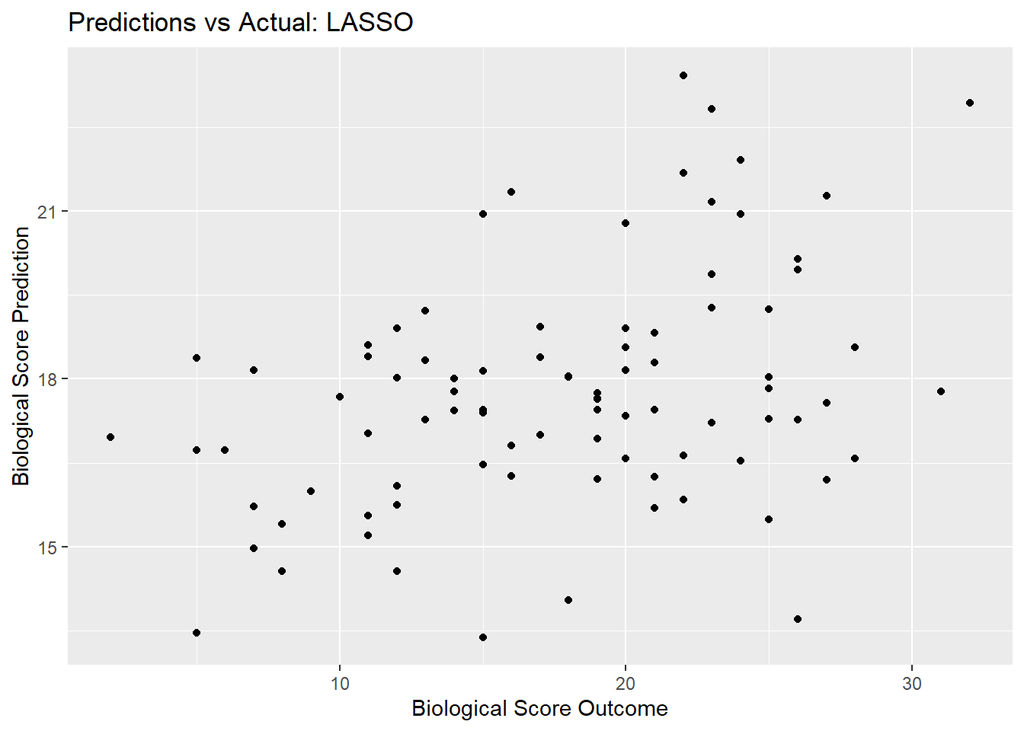

```r
lasso_pred_plot <- ggplot(lasso_residuals,
                          aes(x = biological_score,
                              y = .pred)) +
  geom_point() +
  labs(title = "Predictions vs Actual: LASSO",
       x = "Biological Score Outcome",
       y = "Biological Score Prediction")
lasso_pred_plot
```

*plot residuals vs predictions*

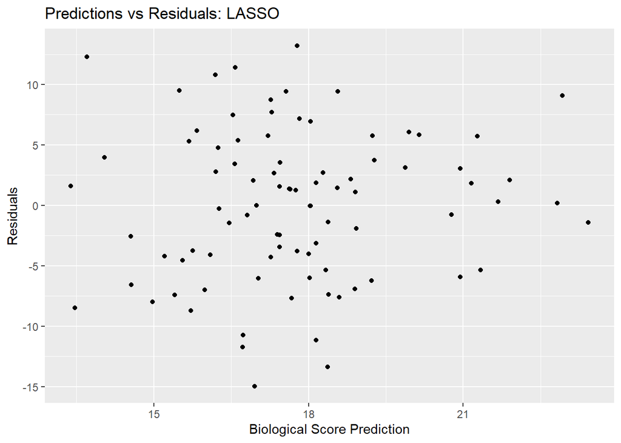

```r
lasso_residual_plot <- ggplot(lasso_residuals,
                              aes(y = .resid,
                                  x = .pred)) +
  geom_point() +
  labs(title = "Predictions vs Residuals: LASSO",
       x = "Biological Score Prediction",
       y = "Residuals")
plot(lasso_residual_plot) #view plot
```

# LASSO: E. coli cfu

## Data Set Up:

*Set seed: This sets a random number generator with initial (pseudo)random values set as “123”. We will need a series of random numbers created for our machine learning analysis.*

```r
#Set random number generator.
set.seed(123)
```

## Null Model For MIDO Data

```r
#Create folds for LASSO Cross Validation.
fold_EC <- vfold_cv(MIDO_LASSO, v = 5, repeats = 5, strata = e.coli.cfu)
```

*Creating the recipe for E. coli cfu vs all predictors*

```r
EC.recipe <-
  recipe(e.coli.cfu ~ ., data = MIDO_LASSO) %>%
  step_zv(all_predictors()) %>%
  step_normalize(all_predictors())

EC.recipe
```

```
## Recipe
##
## Inputs:
##
##       role #variables
##    outcome          1
##  predictor          4
##
## Operations:
##
## Zero variance filter on all_predictors()
## Centering and scaling for all_predictors()
```

*Setting linear regression model to assess relationship between E. coli cfu (outcome) and all other predictor variables.*

```r
lm_mod <- linear_reg() %>% set_engine("lm") %>% set_mode("regression")
```

*However, first we need to create our null model to test against.*

### Null Model:

*Creates null model recipe. When we call this term, it will indicate in our workflow that E. Coli cfu will be predicted by a value of 1 (NULL).*

```r
Null_recipe_lm_EC <- recipe(e.coli.cfu ~ 1, data = MIDO_LASSO)
```

*Creating the Workflow: this creates a set workflow for running a null linear regression model with E. coli cfu as the outcome.*

```r
null_wf_EC <- workflow() %>% add_model(lm_mod) %>% add_recipe(Null_recipe_lm_EC)
```

```r
null_lm_EC <- fit_resamples(null_wf_EC, resamples = fold_EC)
```

[output not shown]

[output not shown]

[output not shown]

[output not shown]

[output not shown]

[output not shown]

[output not shown]

[output not shown]

[output not shown]

[output not shown]

[output not shown]

[output not shown]

[output not shown]

[output not shown]

[output not shown]

[output not shown]

[output not shown]

[output not shown]

[output not shown]

[output not shown]

[output not shown]

[output not shown]

[output not shown]

[output not shown]

[output not shown]

```r
Null_Met_EC <- collect_metrics(null_lm_EC)

Null_Met_EC
```

```
## # A tibble: 2 x 6
##   .metric .estimator    mean     n std_err .config
##   <chr>   <chr>        <dbl> <int>   <dbl> <chr>
## 1 rmse    standard     0.524    25  0.0139 Preprocessor1_Model1
## 2 rsq     standard   NaN         0 NA      Preprocessor1_Model1
```

*RMSE = 0.52, with a standard deviation of 0.014. This will serve as our check to test our models against latter on.*

## LASSO Model

*Specifying The Model: LASSO*

```r
lasso_mod <-
  linear_reg(penalty = tune(), mixture = 1) %>%
  set_engine("glmnet")
```

*Creating a Workflow: LASSO*

```r
lasso_wf_EC <- workflow() %>%
  add_model(lasso_mod) %>%
  add_recipe(EC.recipe)
```

*Create Tuning Grid: LASSO*

```r
LASSO_grid <- grid_regular(penalty(), levels = 50)
```

*Cross Validation with tune_grid(): LASSO*

```r
lasso_resample_EC <-
  lasso_wf_EC %>%
  tune_grid(resamples = fold_EC,
            grid = LASSO_grid,
            control = control_grid(verbose = FALSE, save_pred = TRUE),
            metrics = metric_set(rmse))

lasso_resample_EC %>%
  collect_metrics()
```

```
## # A tibble: 50 x 7
##     penalty .metric .estimator  mean     n std_err .config
##       <dbl> <chr>   <chr>      <dbl> <int>   <dbl> <chr>
##  1 1   e-10 rmse    standard   0.505    25  0.0118 Preprocessor1_Model01
##  2 1.60e-10 rmse    standard   0.505    25  0.0118 Preprocessor1_Model02
##  3 2.56e-10 rmse    standard   0.505    25  0.0118 Preprocessor1_Model03
##  4 4.09e-10 rmse    standard   0.505    25  0.0118 Preprocessor1_Model04
##  5 6.55e-10 rmse    standard   0.505    25  0.0118 Preprocessor1_Model05
##  6 1.05e- 9 rmse    standard   0.505    25  0.0118 Preprocessor1_Model06
##  7 1.68e- 9 rmse    standard   0.505    25  0.0118 Preprocessor1_Model07
##  8 2.68e- 9 rmse    standard   0.505    25  0.0118 Preprocessor1_Model08
##  9 4.29e- 9 rmse    standard   0.505    25  0.0118 Preprocessor1_Model09
## 10 6.87e- 9 rmse    standard   0.505    25  0.0118 Preprocessor1_Model10
## # ... with 40 more rows
```

*Plot model performance using autoplot()*

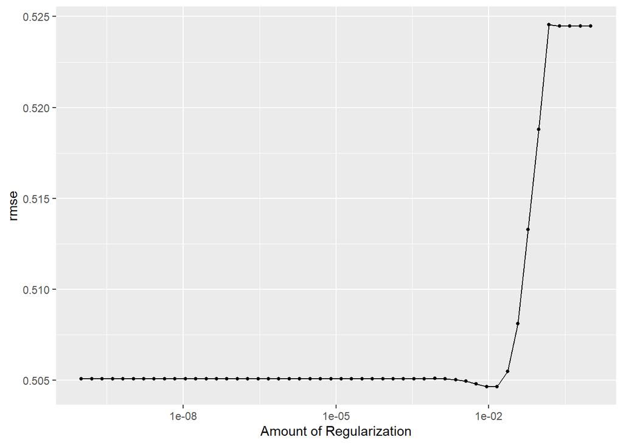

```r
#Plot of MIDO data LASSO model performance
lasso_resample_EC %>%
  autoplot()
```

*Showing and selecting best performing Models*

```r
#Showing best performing LASSO models
lasso_resample_EC %>%
  show_best()
```

```
## # A tibble: 5 x 7
##   penalty .metric .estimator  mean     n std_err .config
##     <dbl> <chr>   <chr>      <dbl> <int>   <dbl> <chr>
## 1 0.0146  rmse    standard   0.505    25  0.0122 Preprocessor1_Model41
## 2 0.00910 rmse    standard   0.505    25  0.0120 Preprocessor1_Model40
## 3 0.00569 rmse    standard   0.505    25  0.0119 Preprocessor1_Model39
## 4 0.00356 rmse    standard   0.505    25  0.0119 Preprocessor1_Model38
## 5 0.00222 rmse    standard   0.505    25  0.0118 Preprocessor1_Model37
```

```r
#Selects best performing model
best_lasso_EC <- lasso_resample_EC %>%
  select_best()
```

*This shows that model 41 is the best performing models (RMSE = 0.50; STE = 0.012). However, it doesn’t really perform any better than the null model, making it a bad fit to the data.*

*Creating final fit based on best model permutation and plotting predicted values from that final fit model*

```r
lasso_final_wf_EC <-
  lasso_wf_EC %>%
  finalize_workflow(best_lasso_EC)

lasso_final_wf_EC
```

```
## == Workflow ====================================================================
## Preprocessor: Recipe
## Model: linear_reg()
##
## -- Preprocessor ----------------------------------------------------------------
## 2 Recipe Steps
##
## * step_zv()
## * step_normalize()
##
## -- Model -----------------------------------------------------------------------
## Linear Regression Model Specification (regression)
##
## Main Arguments:
##   penalty = 0.0145634847750124
##   mixture = 1
##
## Computational engine: glmnet
```

```r
#Create workflow for fitting model to train_data2 predictions
lasso_final_fit_EC <-
  lasso_final_wf_EC %>%
  fit(MIDO_LASSO)
```

*Calculating residuals:*

```r
#Manually calculate residuals for MIDO data LASSO models between real and predicted values.
lasso_residuals_EC <- lasso_final_fit_EC %>%
  augment(MIDO_LASSO) %>% #use augment() to make predictions from train data
  select(c(.pred, e.coli.cfu)) %>%
  mutate(.resid = e.coli.cfu - .pred) #calculate residuals and make new row.

lasso_residuals_EC
```

```
## # A tibble: 88 x 3
##    .pred e.coli.cfu .resid
##    <dbl>      <dbl>  <dbl>
##  1  2.53       1.93 -0.597
##  2  2.27       1.93 -0.344
##  3  2.60       2.43 -0.172
##  4  2.51       1.61 -0.900
##  5  2.43       2.75  0.322
##  6  2.59       1.87 -0.719
##  7  2.49       3.84  1.35
##  8  2.60       2.77  0.161
##  9  2.43       3.33  0.899
## 10  2.37       1.30 -1.07
## # ... with 78 more rows
```

*model predictions from tuned model vs actual outcomes*

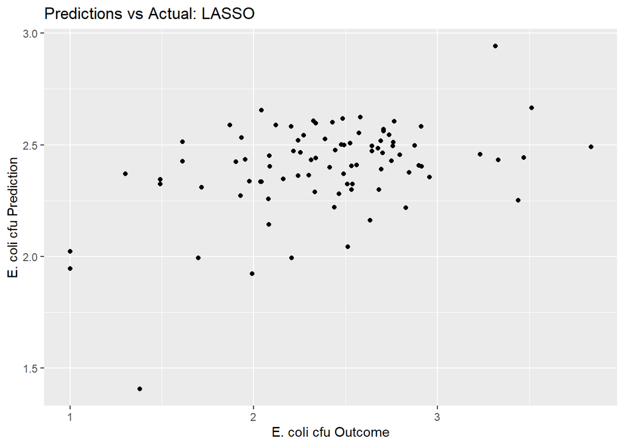

```r
lasso_pred_plot_EC <- ggplot(lasso_residuals_EC,
                          aes(x = e.coli.cfu,
                              y = .pred)) +
  geom_point() +
  labs(title = "Predictions vs Actual: LASSO",
       x = "E. coli cfu Outcome",
       y = "E. coli cfu Prediction")
lasso_pred_plot_EC
```

*plot residuals vs predictions*

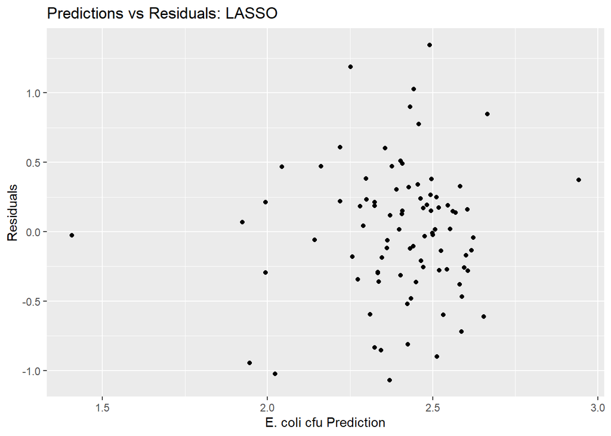

```r
lasso_residual_plot_EC <- ggplot(lasso_residuals_EC,
                              aes(y = .resid,
                                  x = .pred)) +
  geom_point() +
  labs(title = "Predictions vs Residuals: LASSO",
       x = "E. coli cfu Prediction",
       y = "Residuals")
plot(lasso_residual_plot_EC) #view plot
```